# Homework 6

Gwen Ellis

2024-02-21

# Mammal BMR data set

Data is from Phylogeny and metabolic scaling in mammals (2010) Capellini et al.

### read in data and clean it

```r
mammal_df <- read.csv("mammal_bmr.csv", sep=",", comment.char='#')
str(mammal_df)
```

```
## 'data.frame':    623 obs. of  9 variables:
##  $ Subclass              : chr  "Eutheria" "Eutheria" "Eutheria" "Eutheria" ...
##  $ Order                 : chr  "Afrosoricida" "Afrosoricida" "Afrosoricida" "Afrosoricida" ...
##  $ Species               : chr  "Amblysomus hottentotus" "Chrysochloris asiatica" "Echinops telfari" "Geogale aurita" ...
##  $ BMR..mlO2.hour.       : num  84.7 51.48 133.9 7.73 64.1 ...
##  $ Body.mass.for.BMR..gr.: num  70 44 116.4 6.9 133 ...
##  $ Reference.for.BMR     : chr  "White&Seymour03PNAS" "White et al06BiolLett" "White&Seymour03PNAS" "White et al06BiolLett" ...
##  $ FMR..kJ.day.          : num  -9999 -9999 -9999 -9999 -9999 ...
##  $ Body.mass.for.FMR..gr.: num  -9999 -9999 -9999 -9999 -9999 ...
##  $ Reference.for.FMR     : chr  "-9999" "-9999" "-9999" "-9999" ...
```

```r
mammal_df$BMR <- mammal_df$BMR..mlO2.hour. # copying BMR column to a new column
mammal_df[(mammal_df$BMR == -9999),] = NA # fix weird method for assigning missing values
mammal_df <- na.omit(mammal_df)
summary(mammal_df$BMR) # maximum BMR is ~51,000
```

```
##     Min.  1st Qu.   Median     Mean  3rd Qu.     Max.
##     6.12    45.19    98.60   901.31   368.32 51419.00
```

```r
mammal_df <- mammal_df %>%
  mutate(BMR=log(BMR..mlO2.hour.)) # log transformation the BMRs
sum(mammal_df$BMR > 8) # only 30 samples (out of 580) are larger than 10^8 so I'm going to filter those out since it makes the data very hard to view (long tail)
```

```
## [1] 30
```

```r
mammal_df <- mammal_df %>%
  filter(BMR <= 8)
```

### plot data

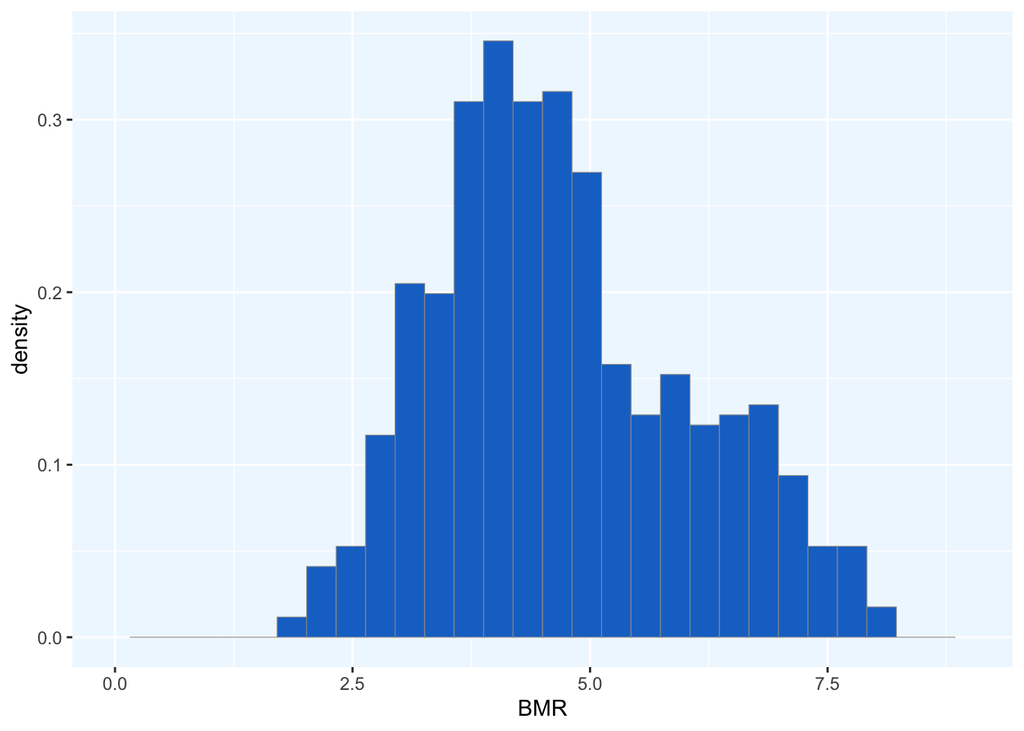

```r
p1 <- ggplot(data=mammal_df, aes(x=BMR, y=..density..)) +
  xlim(0,9) +
  geom_histogram(color="grey60",fill="dodgerblue3",size=0.2) +
  theme(panel.background=element_rect(fill = "aliceblue"))
print(p1)
```

### Add empirical density curve

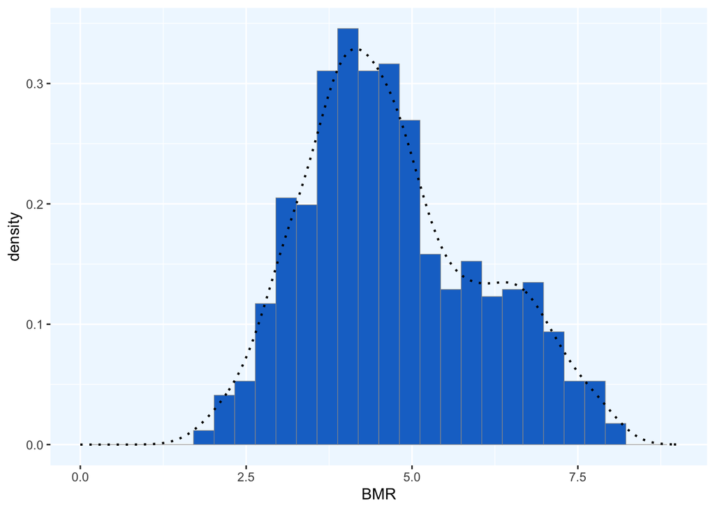

```r
p1 <-  p1 +  geom_density(linetype="dotted",size=0.75)
print(p1)
```

### Get maximum likelihood parameters for a normal distribution

```r
normPars <- fitdistr(mammal_df$BMR,"normal")
print(normPars)
```

```
##       mean          sd
##   4.71494765   1.32549513
##  (0.05651930) (0.03996518)
```

```r
 #      mean          sd
 #  4.71494765   1.32549513
 # (0.05651930) (0.03996518)
str(normPars)
```

```
## List of 5
##  $ estimate: Named num [1:2] 4.71 1.33
##   ..- attr(*, "names")= chr [1:2] "mean" "sd"
##  $ sd      : Named num [1:2] 0.0565 0.04
##   ..- attr(*, "names")= chr [1:2] "mean" "sd"
##  $ vcov    : num [1:2, 1:2] 0.00319 0 0 0.0016
##   ..- attr(*, "dimnames")=List of 2
##   .. ..$ : chr [1:2] "mean" "sd"
##   .. ..$ : chr [1:2] "mean" "sd"
##  $ n       : int 550
##  $ loglik  : num -935
##  - attr(*, "class")= chr "fitdistr"
```

```r
normPars$estimate["mean"] # note structure of getting a named attribute
```

```
##     mean
## 4.714948
```

```r
# 4.714948
```

### plot the normal distribution probability density

```r
meanML <- normPars$estimate["mean"]
sdML <- normPars$estimate["sd"]

xval <- seq(0,max(mammal_df$BMR),len=length(mammal_df$BMR))

 stat <- stat_function(aes(x = xval, y = ..y..), fun = dnorm, colour="red", n = length(mammal_df$BMR), args = list(mean = meanML, sd = sdML))
 p1 + stat
```

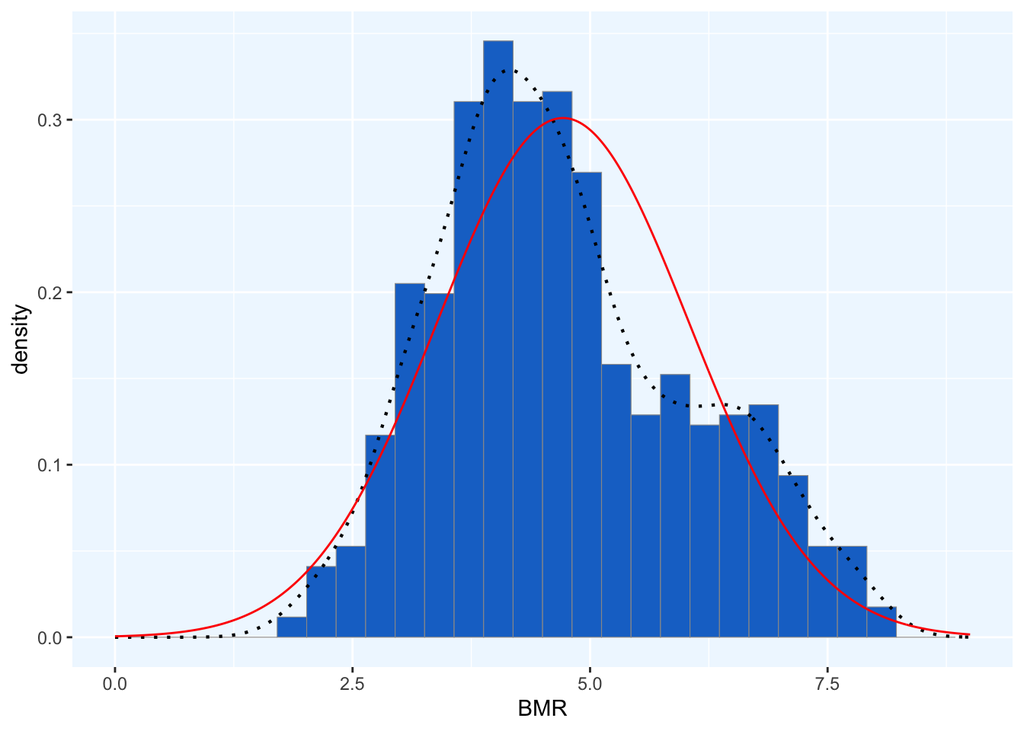

Normal distribution doesn’t look awful, but this dataset has no zeroes so the normal distribution appears skewed right

### Plot exponential probability density

```r
expoPars <- fitdistr(mammal_df$BMR,"exponential")
rateML <- expoPars$estimate["rate"]

stat2 <- stat_function(aes(x = xval, y = ..y..), fun = dexp, colour="orange2", n = length(mammal_df$BMR), args = list(rate=rateML))
 p1 + stat + stat2
```

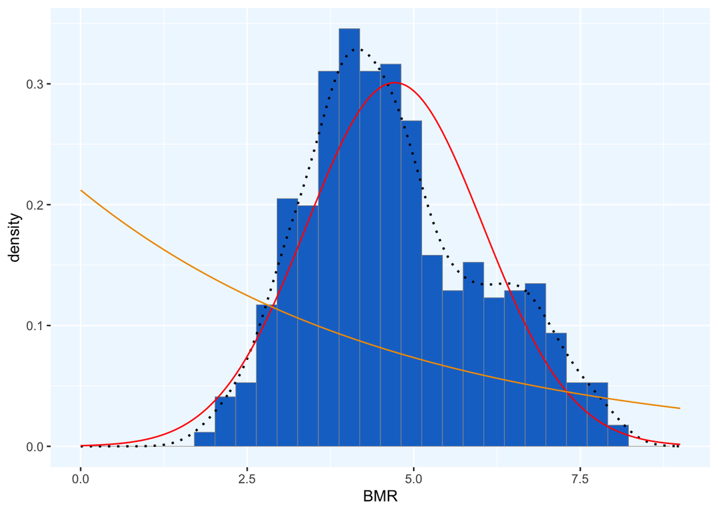

This looks even worse than a normal distribution.

### Plot uniform probability density

```r
stat3 <- stat_function(aes(x = xval, y = ..y..), fun = dunif, colour="green4", n = length(mammal_df$BMR), args = list(min=min(mammal_df$BMR), max=max(mammal_df$BMR)))
 p1 + stat + stat2 + stat3
```

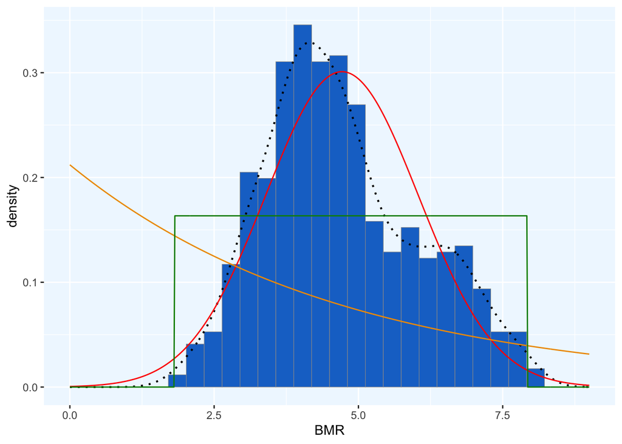

The data is definitely not uniform

### Plot gamma probability density

```r
gammaPars <- fitdistr(mammal_df$BMR,"gamma")
shapeML <- gammaPars$estimate["shape"]
rateML <- gammaPars$estimate["rate"]

stat4 <- stat_function(aes(x = xval, y = ..y..), fun = dgamma, colour="hotpink3", n = length(mammal_df$BMR), args = list(shape=shapeML, rate=rateML))
 p1 + stat + stat2 + stat3 + stat4
```

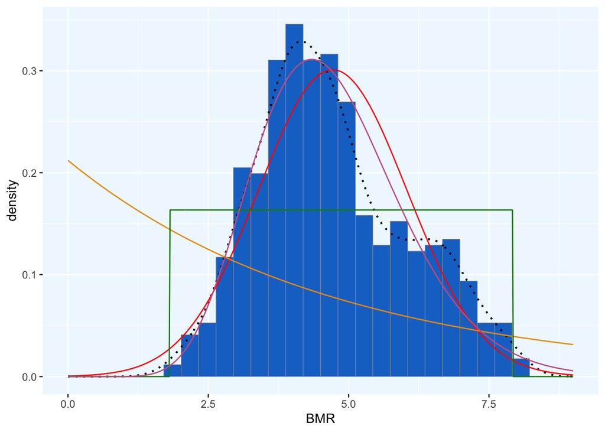

Since a gamma distribution is basically a zero bounded normal distribution, this fits pretty well to the data

### Plot beta probability density

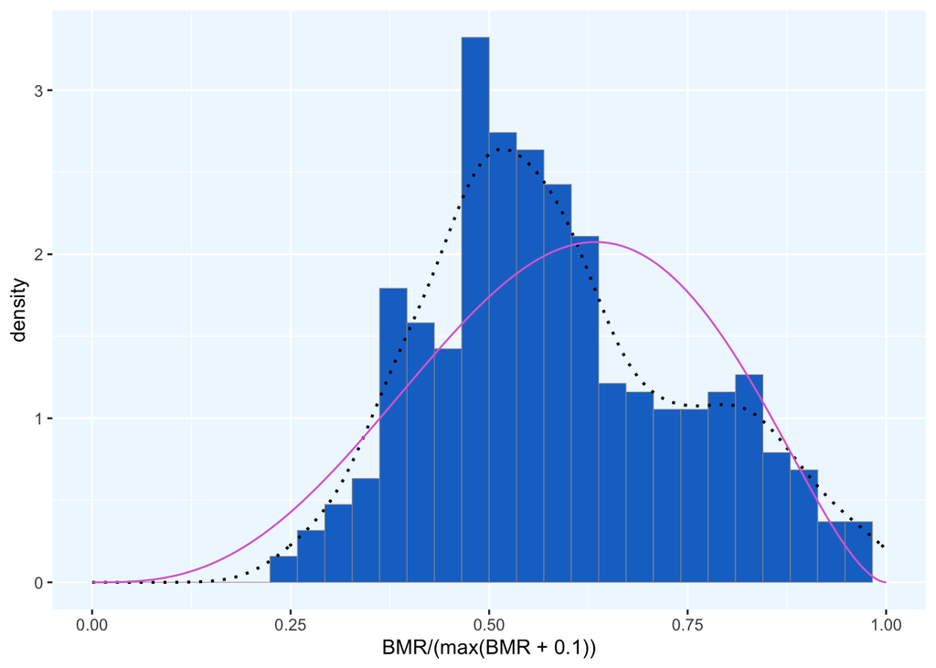

```r
pSpecial <- ggplot(data=mammal_df, aes(x=BMR/(max(BMR + 0.1)), y=..density..)) +
  geom_histogram(color="grey60",fill="dodgerblue3",size=0.2) +
   theme(panel.background=element_rect(fill = "aliceblue")) +
  xlim(c(0,1)) +
  geom_density(size=0.75,linetype="dotted")

betaPars <- fitdistr(x=mammal_df$BMR/max(mammal_df$BMR + 0.1),start=list(shape1=1,shape2=2),"beta")
shape1ML <- betaPars$estimate["shape1"]
shape2ML <- betaPars$estimate["shape2"]

statSpecial <- stat_function(aes(x = xval, y = ..y..), fun = dbeta, colour="orchid", n = length(mammal_df$BMR), args = list(shape1=shape1ML,shape2=shape2ML))
pSpecial + statSpecial
```

Beta distribution requires rescaling the data to be bounded by 0 and 1, but otherwise this fits the observed probability distribution pretty well, but I don’t think as well as the gamma distribution

Based on the above graphs, I think that the gamma distribution fits the data best. This makes sense since the data is on BMR of mammals which have to be above zero and are also limited by the mammal’s size. This data set might be slightly skewed towards mammals with lower BMR.

# Using simulated data

```r
# Get maximum likelihood parameters for a gamma distribution
gammaPars <- fitdistr(mammal_df$BMR,"gamma")
print(gammaPars)
```

```
##      shape         rate
##   12.6297495    2.6787878
##  ( 0.7517515) ( 0.1626546)
```

```r
 #     shape         rate
 #  12.6297495    2.6787878
 # ( 0.7517515) ( 0.1626546)
str(gammaPars)
```

```
## List of 5
##  $ estimate: Named num [1:2] 12.63 2.68
##   ..- attr(*, "names")= chr [1:2] "shape" "rate"
##  $ sd      : Named num [1:2] 0.752 0.163
##   ..- attr(*, "names")= chr [1:2] "shape" "rate"
##  $ vcov    : num [1:2, 1:2] 0.5651 0.1199 0.1199 0.0265
##   ..- attr(*, "dimnames")=List of 2
##   .. ..$ : chr [1:2] "shape" "rate"
##   .. ..$ : chr [1:2] "shape" "rate"
##  $ loglik  : num -922
##  $ n       : int 550
##  - attr(*, "class")= chr "fitdistr"
```

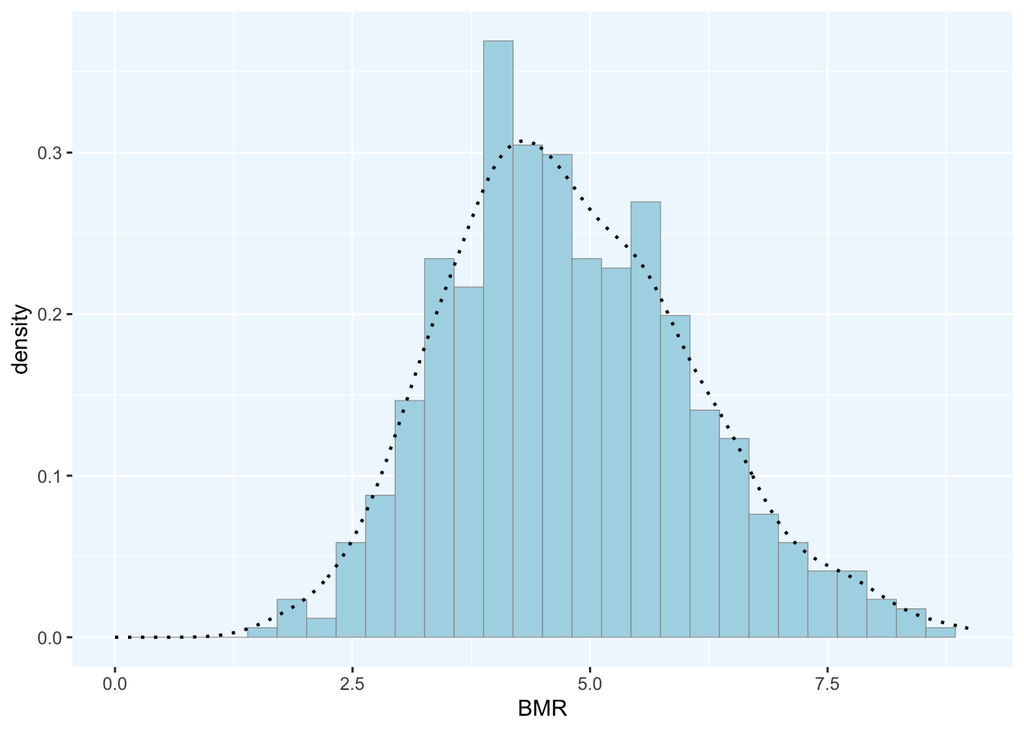

```r
sim_shape <- gammaPars$estimate["shape"] # 12.6297495
sim_rate <- gammaPars$estimate["rate"] # 2.678788

sim_gamma <- data.frame(rgamma(n=length(mammal_df$BMR), shape=sim_shape, rate=sim_rate))
sim_gamma$BMR <- sim_gamma$rgamma.n...length.mammal_df.BMR...shape...sim_shape..rate...sim_rate. # add new column

p2 <- ggplot(data=sim_gamma, aes(x=BMR, y=..density..)) +
  xlim(0,9) +
  theme(panel.background=element_rect(fill = "aliceblue")) +
  geom_histogram(color="grey60",fill="lightblue",size=0.2) # new histrogram from simulated data

p2 <-  p2 + geom_density(linetype="dotted",size=0.75) # add density curve
print(p2)
```

```r
sim_stat <- stat_function(aes(x = xval, y = ..y..), fun = dgamma, colour="hotpink3", n = length(sim_gamma$BMR), args = list(shape=sim_shape, rate=sim_rate))
 p2 + sim_stat
```

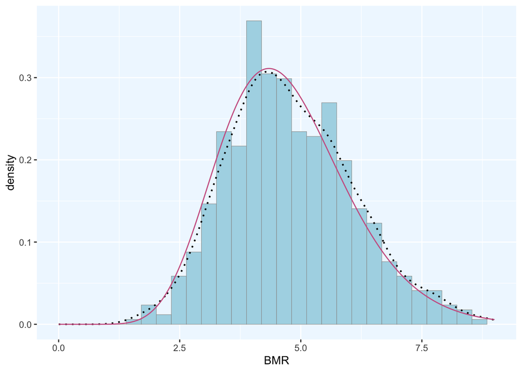